# funqtl: QTL mapping with function-valued traits

This vignette illustrates the use of the funqtl package for QTL mapping with function-valued traits (e.g., growth measured over time).

## Data

We will consider the analysis of a simulated data set, `simspal`. There are 162 recombinant inbred lines typed at a total of 234 markers on 5 chromosomes.

We first load the funqtl package (which will also load R/qtl and other packages) and the data.

```r
library(funqtl)
data(simspal)
```

Here's a quick summary of the data.

```r
summary(simspal)
```

```
##     RI strains via selfing
##
##     No. individuals:    162
##
##     No. phenotypes:     241
##     Percent phenotyped: 100
##
##     No. chromosomes:    5
##         Autosomes:      1 2 3 4 5
##
##     Total markers:      234
##     No. markers:        26 42 64 35 67
##     Percent genotyped:  98.6
##     Genotypes (%):      AA:49.8  BB:50.2
```

The following plots the genetic marker map and the function-valued trait for five of the RIL.

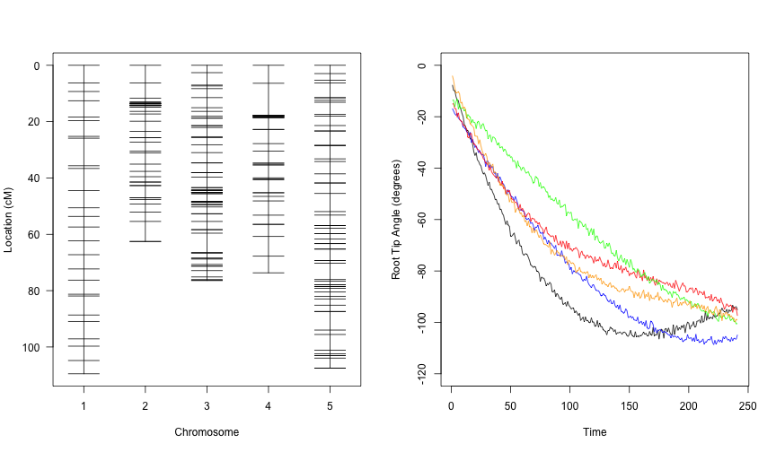

```r
par(mfrow=c(1,2))
plotMap(simspal, main="")
plot(1:241, simspal$pheno[160,], type="l", xlab="Time", ylim=c(-120,0),
     ylab="Root Tip Angle (degrees)")
ind <- c(19, 20, 132, 72)
color <- c("blue", "red", "green", "orange")
for(i in seq(along=ind))
  lines(1:241, simspal$pheno[ind[i],], col=color[i])
```

## Single-QTL analysis at the individual time points

We first perform single-QTL genome scans at each time point, individually.

We use `calc.genoprob` in R/qtl to calculate QTL genotype probabilities and then `scanone` to perform the genome scans, using Haley-Knott regression (Haley and Knott 1992). We'll perform calculations solely at the marker positions (`step=0`) to speed up the calculations.

```r
n.phe <- nphe(simspal)
simspal <- calc.genoprob(simspal, step=0)
out <- scanone(simspal, pheno.col = 1:n.phe, method="hk")
```

The function `geteffects` estimates the QTL effect at each locus, for each time point.

```r
eff <- geteffects(simspal, pheno.cols=1:n.phe)
```

The function `plotlod` plots a heat map of signed LOD scores: the LOD scores, taking the signs of the estimated effects.

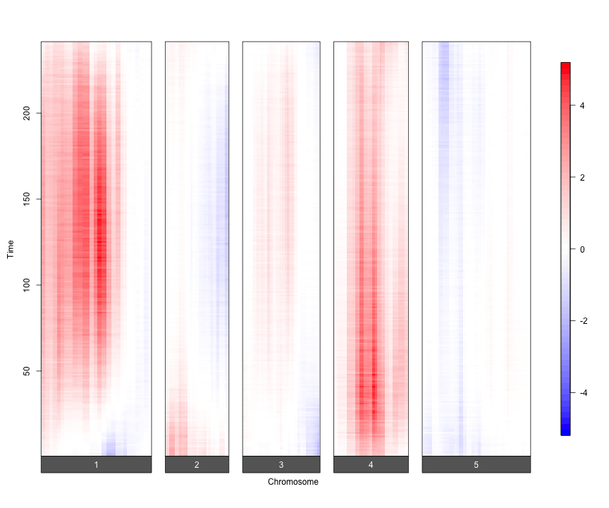

```r
plotlod(out, eff, gap=15, main="The LOD image of the simspal data set",
        ylab="Time")
```

The x-axis represents genomic position and the y-axis represents time, and so each horizontal slice is a genome scan for one time point. We plot a signed LOD score, with the sign representing the estimated direction of the QTL effect. The most prominant QTL are on chromosomes 1 and 4.

## SLOD and MLOD scores

```r
out1 <- scanoneF(simspal, pheno.cols = 1:241, method="hk")
```

The SLOD and MLOD statistics combine the results across time points, by taking the average or the maximum LOD, respectively, at each genomic location.

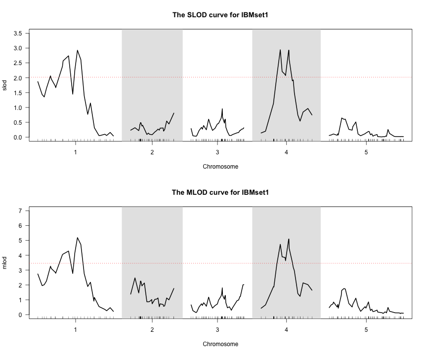

```r
par(mfrow=c(2,1))
plot(out1, ylim=c(0,3.5), main="The SLOD curve for IBMset1", bandcol="gray90")
abline(h=2.02, col="red", lty=3)
plot(out1[,c(1,2,4)], ylim=c(0,7), main="The MLOD curve for IBMset1", bandcol="gray90")
abline(h=3.46, col="red", lty=3)
```

```r
# permutation threshold
# permout <- scanoneF(simspal, pheno.cols=1:241, method = "hk", n.perm=1000)
# summary(permout) # display 5, 10 % threshold of permutation result
```

The results are in Figure above. Horizontal lines indicate the 5% genome-wide significance thresholds, derived by a permutation test. We didn't run the code above since it takes a long time (about one hour maybe) .

## Getting multiple QTL

```r
#qtlslod <- stepwiseqtlF(simspal, pheno.cols = 1:241, max.qtl = 6,
#                       usec = "slod", method = "hk", penalties = c(2.02, 2.62, 1.74) )
simspal <- calc.genoprob(simspal, step=0)
qtlslod <- makeqtl(simspal, chr = c(1, 4),
               pos = c(36.6, 27.8), what = "prob")
```

`stepwiseqtlF` function returns qtl object by using stepwise QTL selection. It takes long time to run this function, so I run `makeqtl` function to get the result of `stepwiseqtlF` function. You will get the same result if you run `stepwiseqtlF` function.

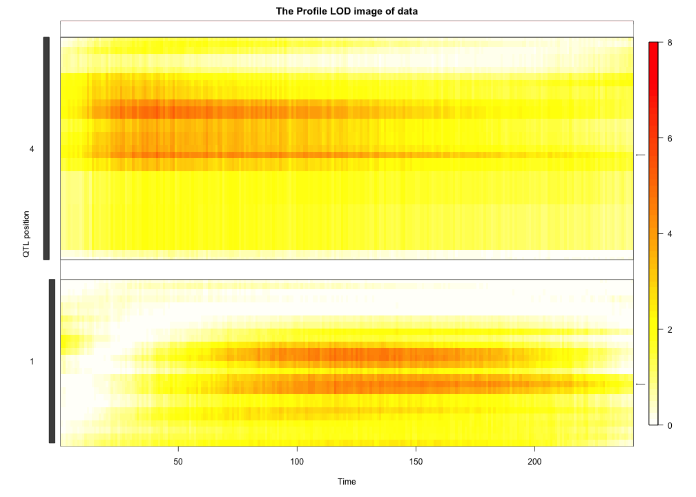

```r
lodmat1.c <- getprofile(simspal, qtl =  qtlslod, pheno.cols =1:241,
                             formula = y~Q1 + Q2 , method = "hk",
                              verbose = F, tpy="comb")
plotprofile(lodmat1.c, mval = 8, col=heat.colors(100)[100:1], main="The Profile LOD image of data")
```

You can get profilelod image by using `getprofile` function and `plotprofile` function. You need to have an option `step = 0` in `calc.genoprob` function.

## Effect plot

```r
slodeff <- vector("list", nphe(simspal))

for(i in 1:nphe(simspal)) {
    slodeff[[i]] <- summary(fitqtl(simspal, phe=i, qtl=qtlslod,
                            method="hk", get.ests=TRUE, dropone=FALSE))$ests[,1]*c(1,2,2)
}

nam <- names(slodeff[[1]])
slodeff <- matrix(unlist(slodeff), byrow=TRUE, ncol=length(nam))
colnames(slodeff) <- nam

time <- (0:240)/30
```

To further characterize the effects of the QTL in the context of the inferred multiple-QTL models, we fit the selected multiple-QTL models at each time point, individually. the estimated baseline function and the estimated QTL effects, as a function of time. The estimated QTL effects in panels are for the difference between two alleles.

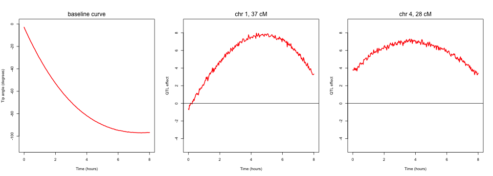

```r
par(mfrow=c(1,3))
plot(time, slodeff[,1], lwd=2, type="l",
     xlab="Time (hours)",
          ylab="Tip angle (degrees)", col="red", ylim=c(-110,0))
          mtext("baseline curve", side=3, line=0.5)

plot(time, slodeff[,2], lwd=2, ylim = c(-5,9), type="l",
     xlab="Time (hours)",
          ylab="QTL effect", col="red")
          abline(h=0)
          mtext("chr 1, 37 cM", side=3, line=0.5)

plot(time, slodeff[,3], lwd=2, ylim = c(-5,9), type="l",
     xlab="Time (hours)",
          ylab="QTL effect", col="red")
          mtext("chr 4, 28 cM", side=3, line=0.5)
          abline(h=0)
```